# Distributional Mediation Analysis

## Beyond the Mean: Why Distributional Mediation?

Traditional mediation analysis focuses on decomposing the **Average Treatment Effect (ATE)** into the **Natural Direct Effect (NDE)** and the **Natural Indirect Effect (NIE)**. While these provide a useful summary, they only describe the “center” of the causal response.

Causal mechanisms often shift the **shape**, **variance**, or **modality** of an outcome without necessarily shifting its mean. Energy Regression (`engression`) allows us to recover the entire counterfactual distribution $P(Y | do(A=d))$, giving us a much richer picture of the causal process.

## Simulation: The Multi-Modal Response

Consider a scenario where a treatment affects an outcome through a mediator that has a non-linear, squaring effect. Standard linear models or even non-linear mean models might capture the average shift but miss that the treatment introduces extreme values or multi-modality.

### Data Generating Process

- $A \in \{0, 1\}$ (Binary Treatment)
- $M | A \sim N(A, 0.5^2)$ (Mediator shifts its mean with treatment)
- $Y = M^2 + W + \epsilon$ (Outcome is a squared function of the mediator)
- $W \sim N(0, 1)$ (Confounder)

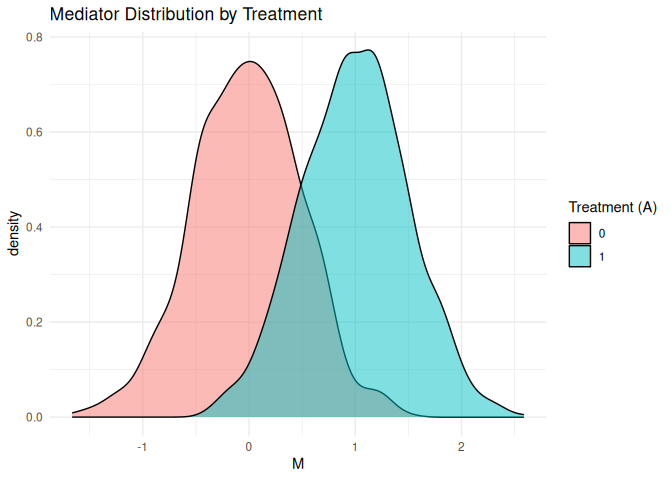

```r
set.seed(42)
n <- 2000
W <- rnorm(n)
A <- rbinom(n, 1, 0.5)
M <- rnorm(n, A, 0.5)
Y <- M^2 + W + rnorm(n, 0, 0.5)
data <- data.frame(A, M, Y, W)

ggplot(data, aes(x = M, fill = factor(A))) +
  geom_density(alpha = 0.5) +
  labs(title = "Mediator Distribution by Treatment", fill = "Treatment (A)") +
  theme_minimal()
```

### Oracle Counterfactual Outcome Distributions

Since we know the DGP, we can compute the true potential outcome distributions under each treatment regime. This is what `plot_counterfactual_density()` aims to recover from data.

Under $do(A=a)$: $M \sim N(a, 0.25)$ and $Y = M^2 + W + \epsilon$, so the outcome distribution changes not just in location but in **shape** — the squared mediator introduces right-skew when $A=1$.

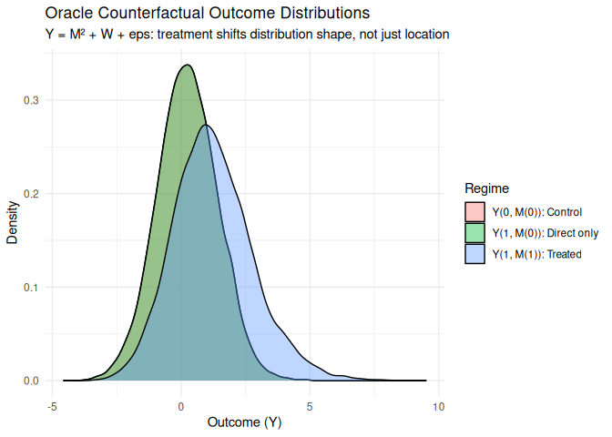

```r
set.seed(42)
n_oracle <- 10000
W_o <- rnorm(n_oracle)
eps_o <- rnorm(n_oracle, 0, 0.5)

# Y(0): do(A=0), M ~ N(0, 0.25)
M0 <- rnorm(n_oracle, 0, 0.5)
Y0 <- M0^2 + W_o + eps_o

# Y(1): do(A=1), M ~ N(1, 0.25)
M1 <- rnorm(n_oracle, 1, 0.5)
Y1 <- M1^2 + W_o + eps_o

# Y(1, M(0)): direct effect — treat but keep mediator at control level
Y10 <- M0^2 + W_o + eps_o  # same as Y0 (no direct effect of A on Y here)

# Y(0, M(1)): indirect effect — don't treat but shift mediator as if treated
Y01 <- M1^2 + W_o + eps_o  # same as Y1

oracle_df <- rbind(
  data.frame(Y = Y0, Regime = "Y(0, M(0)): Control"),
  data.frame(Y = Y1, Regime = "Y(1, M(1)): Treated"),
  data.frame(Y = Y10, Regime = "Y(1, M(0)): Direct only")
)

ggplot(oracle_df, aes(x = Y, fill = Regime)) +
  geom_density(alpha = 0.4) +
  labs(title = "Oracle Counterfactual Outcome Distributions",
       subtitle = "Y = M² + W + eps: treatment shifts distribution shape, not just location",
       x = "Outcome (Y)", y = "Density") +
  theme_minimal()
```

Key observations:

- **Y(0, M(0))** (control): concentrated near zero, since $M \approx 0$ and $M^2 \approx 0$
- **Y(1, M(1))** (treated): shifted right with heavier right tail, since $M \approx 1$ and $M^2 \approx 1$
- **Y(1, M(0))** (direct only) overlaps exactly with control — because $A$ does not enter the outcome equation ($Y = M^2 + W + \epsilon$), treating while holding $M$ at its control level changes nothing. The NDE is zero.
- Since NDE = 0, the entire treatment effect is indirect: **NIE** $= E[Y(1,M(1))] - E[Y(1,M(0))] \approx$ 1, equal to the ATE. But this single number hides the distributional shift from a symmetric, concentrated distribution to a right-skewed one.

Below we fit `dma` and use `plot_counterfactual_density()` to recover this from data, without knowing the true DGP.

## Fitting dma

We fit the `dma` model. Note that we use a sufficient number of epochs to allow the neural networks to learn the squared relationship.

```r
res <- dma(
  data = data, trt = "A", outcome = "Y", mediators = "M", covar = "W",
  d0 = \(data, trt) 0, d1 = \(data, trt) 1,
  effect = "N",
  control = dma_control(
    crossfit_folds = 2L,
    num_epochs = 50L,
    batch_size = 128L,
    riesz_epochs = 10L
  )
)

print(res)
```

```
#>       Estimate: 0.047
#>     Std. error: 0.032
#>       Estimate: 0.954
#>     Std. error: 0.03
#>       Estimate: 1
#>     Std. error: 0.041
```

## Visualizing Results

### Coefficient Plot

The `plot()` method shows point estimates and confidence intervals for all estimated effects:

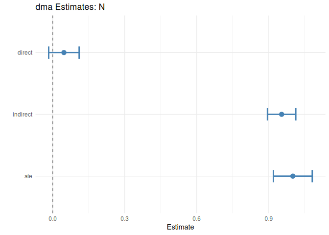

```r
plot(res)
```

### Marginal Counterfactual Densities

The default `plot_counterfactual_density()` shifts the treatment variable and predicts Y from the trained engression models. This shows the marginal outcome distributions $P(Y \mid do(A=0))$ and $P(Y \mid do(A=1))$:

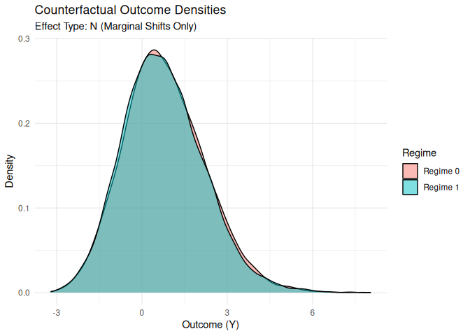

```r
plot_counterfactual_density(res, n_samples = 5)
```

### Mediation Counterfactual Densities

For mediation analysis, we care about the **cross-world** counterfactuals that define the NDE and NIE:

- $Y(0, M(0))$: outcome under control
- $Y(1, M(0))$: outcome under treatment but mediator at control level (defines NDE)
- $Y(1, M(1))$: outcome under full treatment (NIE = difference from $Y(1,M(0))$)

Passing `use_weights = TRUE` uses the learned Riesz representers (density ratios from the mediation cascade) to reweight the observed $Y$ to each counterfactual regime. This is importance sampling: if $\alpha_k$ is the density ratio for regime $k$, then $E[\alpha_k \cdot f(Y)] = E[f(Y(k))]$.

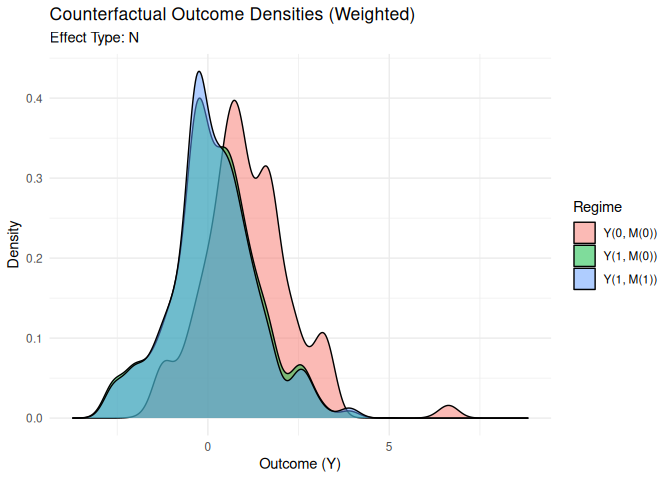

```r
plot_counterfactual_density(res, use_weights = TRUE)
```

### Estimated vs Oracle Comparison

We can overlay the weighted estimates with the oracle distributions for all three mediation regimes:

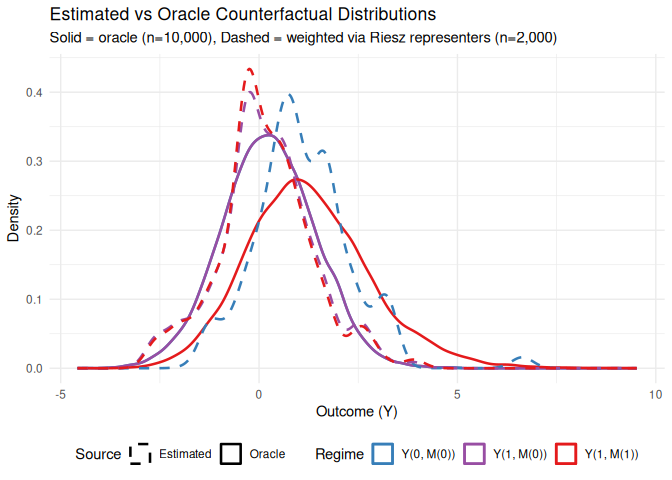

```r
# Weighted estimates
alphas <- res$alpha_n
W <- alphas[["alpha3"]]

df_est <- do.call(rbind, lapply(colnames(W), function(nm) {
  w <- pmax(W[, nm], 0)
  w <- w / sum(w) * length(w)
  data.frame(Y = data$Y, Weight = w, Regime = nm)
}))

regime_map <- c("000" = "Y(0, M(0))", "100" = "Y(1, M(0))", "111" = "Y(1, M(1))")
df_est$Regime <- regime_map[df_est$Regime]

df_oracle <- rbind(
  data.frame(Y = Y0, Regime = "Y(0, M(0))"),
  data.frame(Y = Y10, Regime = "Y(1, M(0))"),
  data.frame(Y = Y1, Regime = "Y(1, M(1))")
)

ggplot() +
  geom_density(data = df_oracle, aes(x = Y, color = Regime, linetype = "Oracle"), linewidth = 0.9) +
  geom_density(data = df_est, aes(x = Y, color = Regime, weight = Weight, linetype = "Estimated"), linewidth = 0.9) +
  scale_color_manual(values = c(
    "Y(0, M(0))" = "#377eb8", "Y(1, M(0))" = "#984ea3", "Y(1, M(1))" = "#e41a1c"
  )) +
  scale_linetype_manual(values = c("Oracle" = "solid", "Estimated" = "dashed")) +
  labs(title = "Estimated vs Oracle Counterfactual Distributions",
       subtitle = "Solid = oracle (n=10,000), Dashed = weighted via Riesz representers (n=2,000)",
       x = "Outcome (Y)", y = "Density", linetype = "Source") +
  theme_minimal() +
  theme(legend.position = "bottom")
```

### Analysis

Traditional methods report the average shift (NIE), but `dma` lets you see how the entire probability mass of the outcome moves — invaluable for understanding treatment mechanisms in non-linear systems.

## Summary

The `dma` package provides:

1. **Valid Causal Estimates**: Doubly-robust estimates of mean effects (NDE, NIE, ATE) with observation weights propagated through all nuisance estimation.
2. **Distributional Insight**: Full counterfactual density visualization via saved `engression` models.
3. **Flexibility**: Robustness to non-linearities and non-Gaussian noise that would violate the assumptions of standard mediation software.